# Clustering and Classification

Let us look at the Boston dataset from MASS package

```r
library(MASS)
data = Boston
str(data)
```

```
## 'data.frame':    506 obs. of  14 variables:
##  $ crim   : num  0.00632 0.02731 0.02729 0.03237 0.06905 ...
##  $ zn     : num  18 0 0 0 0 0 12.5 12.5 12.5 12.5 ...
##  $ indus  : num  2.31 7.07 7.07 2.18 2.18 2.18 7.87 7.87 7.87 7.87 ...
##  $ chas   : int  0 0 0 0 0 0 0 0 0 0 ...
##  $ nox    : num  0.538 0.469 0.469 0.458 0.458 0.458 0.524 0.524 0.524 0.524 ...
##  $ rm     : num  6.58 6.42 7.18 7 7.15 ...
##  $ age    : num  65.2 78.9 61.1 45.8 54.2 58.7 66.6 96.1 100 85.9 ...
##  $ dis    : num  4.09 4.97 4.97 6.06 6.06 ...
##  $ rad    : int  1 2 2 3 3 3 5 5 5 5 ...
##  $ tax    : num  296 242 242 222 222 222 311 311 311 311 ...
##  $ ptratio: num  15.3 17.8 17.8 18.7 18.7 18.7 15.2 15.2 15.2 15.2 ...
##  $ black  : num  397 397 393 395 397 ...
##  $ lstat  : num  4.98 9.14 4.03 2.94 5.33 ...
##  $ medv   : num  24 21.6 34.7 33.4 36.2 28.7 22.9 27.1 16.5 18.9 ...
```

Boston dataset is about housing values in suburbs of Boston. It includes 14 features defining variables that might or might not be relevant for the median value of the houses in that area. The features are:

- crim
  - per capita crime rate by town.
- zn
  - proportion of residential land zoned for lots over 25,000 sq.ft.
- indus
  - proportion of non-retail business acres per town.
- chas
  - Charles River dummy variable (= 1 if tract bounds river; 0 otherwise).
- nox
  - nitrogen oxides concentration (parts per 10 million).
- rm
  - average number of rooms per dwelling.
- age
  - proportion of owner-occupied units built prior to 1940.
- dis
  - weighted mean of distances to five Boston employment centres.
- rad
  - index of accessibility to radial highways.
- tax
  - full-value property-tax rate per $10,000.
- ptratio
  - pupil-teacher ratio by town.
- black
  - 1000(Bk - 0.63)^2 where Bk is the proportion of blacks by town.
- lstat
  - lower status of the population (percent).
- medv
  - median value of owner-occupied homes in $1000s.

Lets grpahically look at the data and summarize the data

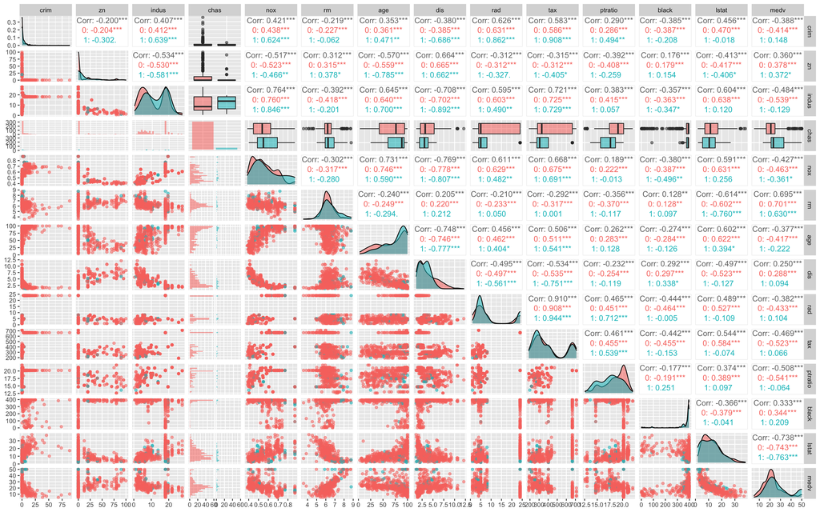

```r
library(ggplot2)
library(GGally)
#lets cast the integers to factors
data$chas = as.factor(data$chas)
ggpairs(data = data, aes(colour = chas, alpha = 0.4))
```